# Data Science Capstone Project Progress Report

H. Chung

8/13/2019

## **1.0 Introduction**

This document presents a brief progress report for the Final Capstone Project of Coursera. The objective of this report is to provide an Exploratory Data Analysis which eventually leads to creating a prediction algorithm application.

## **2.0 Project Objective**

The objective of this project report are:

1. Demonstrate that [the data](https://d396qusza40orc.cloudfront.net/dsscapstone/dataset/Coursera-SwiftKey.zip) has been downloaded and successfully loaded in the local desktop/laptop;
2. Create a basic summary statistics report about the datasets; and
3. Report any interesting findings in the datasets.

## **3.0 Data Exploration**

### 3.1 Downloading and Loading the Data

As previously mentioned, [the data](https://d396qusza40orc.cloudfront.net/dsscapstone/dataset/Coursera-SwiftKey.zip) is to be downloaded and saved locally. After downloading the *zip file*, load the three (3) datasets which will be evaluated:

- en_US.blogs.txt
- en_US.news.txt
- en_US.twitter.txt

*The different codes used in the data exploration can be found [here](https://github.com/hlchung/Capstone-Project)*

### 3.2 Initial Data Summary

The table below shows the summary of the datasets being evaluated and to be used in the predictive algorithm.

| File.Name | File.Size.in.MB | Lines | LinesNEmpty | Chars | CharsNWhite | Word.Count |
| --- | --- | --- | --- | --- | --- | --- |
| en_US.blogs.txt | 200.4242 | 899288 | 899288 | 206824382 | 170389539 | 37570839 |
| en_US.news.txt | 196.2775 | 77259 | 77259 | 15639408 | 13072698 | 2651432 |
| en_US.twitter.txt | 159.3641 | 2360148 | 2360148 | 162096241 | 134082806 | 30451170 |

### 3.3 Obtaining Data Sample for Analysis

The three datasets will be analyzed individually, hence, the number of samples gotten from each dataset will be equal. In this case, a sample of 0.5% of total number of lines are gotten from each file.

### 3.4 Sample Data Cleaning

Afterwards, a Document Term Matrix (DTM) is created for each corpus.

### 3.5 Exploratory Plots

#### **N-Grams Tokenization**

The sample datasets were merged into one file and provides the following evaluation based on N-Grams.

#### 1-Gram

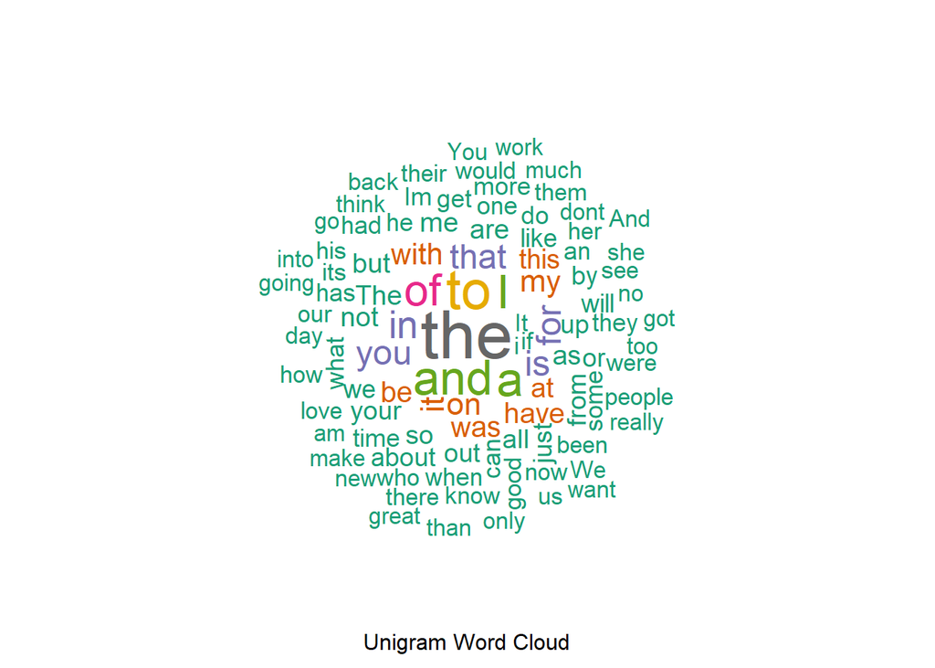

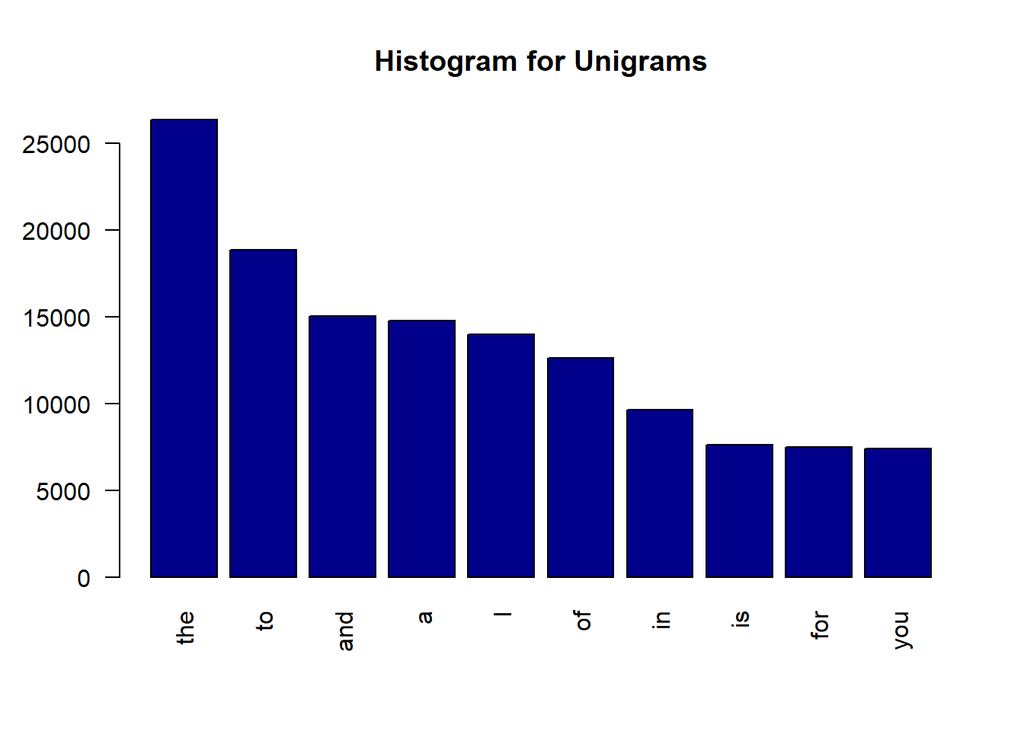

#### 2-Grams

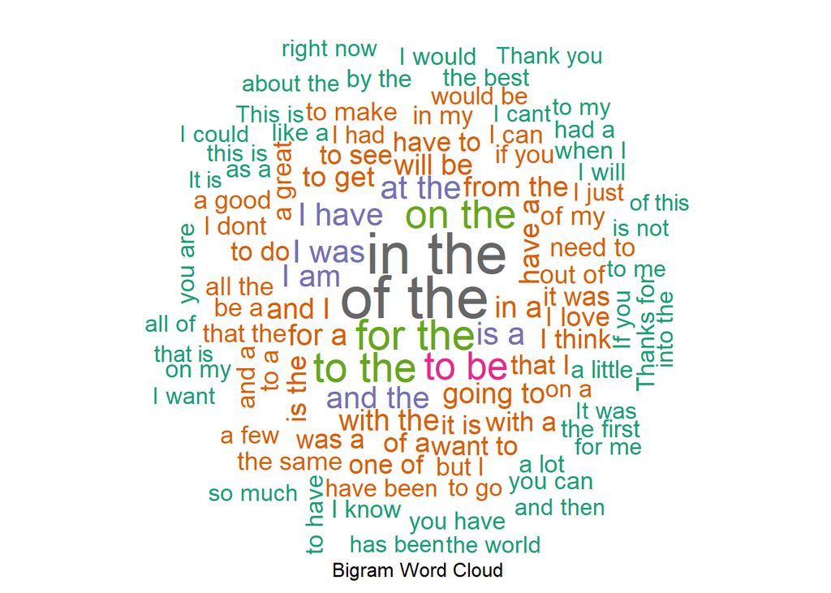

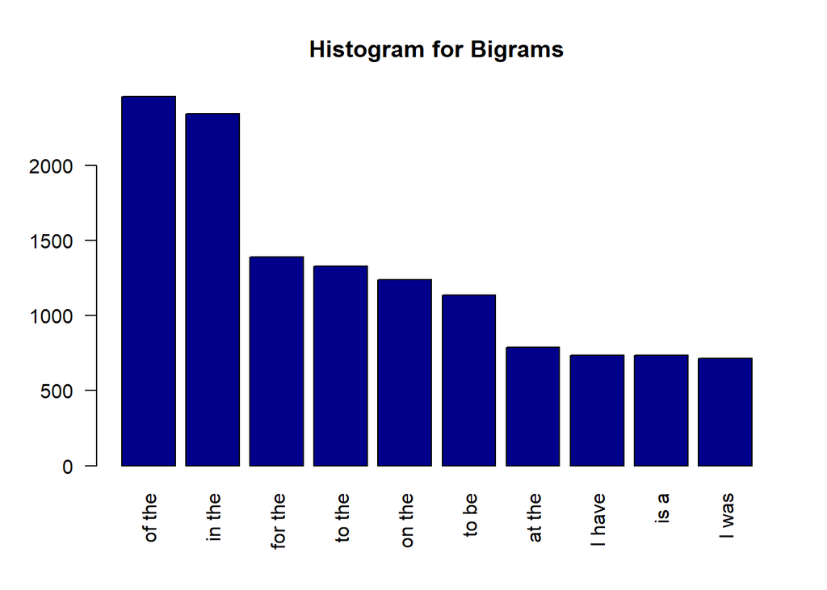

#### 3-Grams

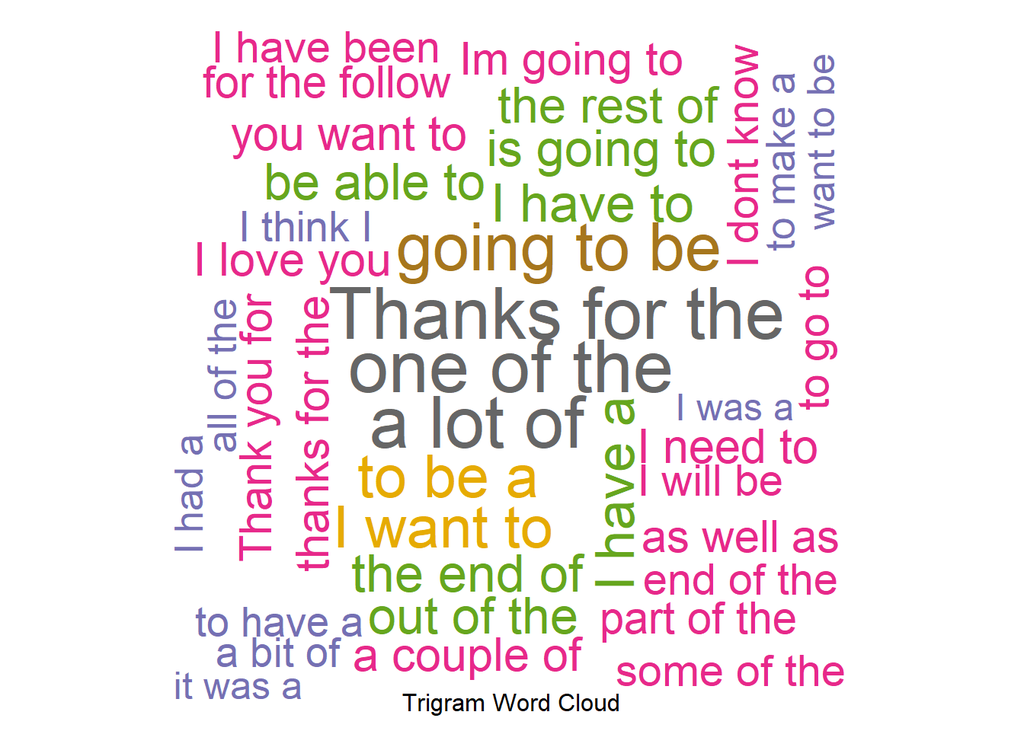

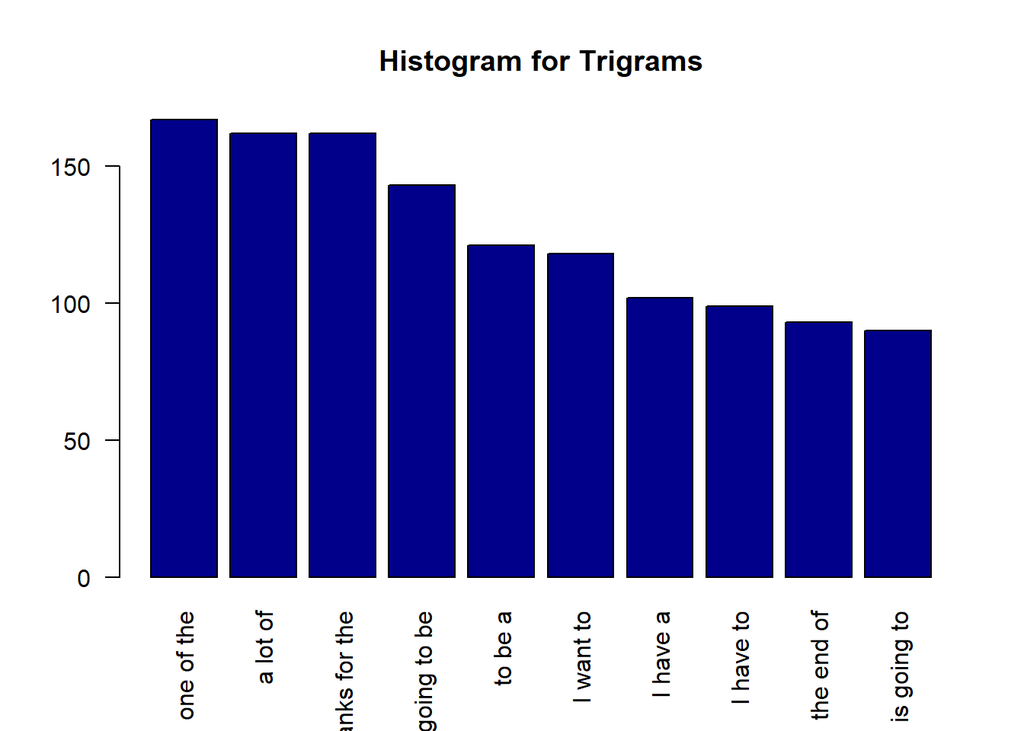

## **4.0 Plans for Final Project**

1. Create a larger corpus size from the original blogs, news and twitter and tokenize it (2-gram and 3-gram). Possible to split the corpus onto multiple parts and create the 2-gram and 3-gram matrix independently then to recombine them as one.
2. Create prediction algorithm by comparing the input to the 2-gram and 3-gram matrix.
3. Optimize the codes to allow faster processing.